# WFM forecasting with R - ARIMA

## Stationarizing Time series data

So how do we stationarize non-stationary time series? The technique depends on the type of non-stationarity observed in the data.

### a. Detrending

**Differencing** is used to remove trends if the series is stationary around a trend. Such time series is usually called *trend stationary*.

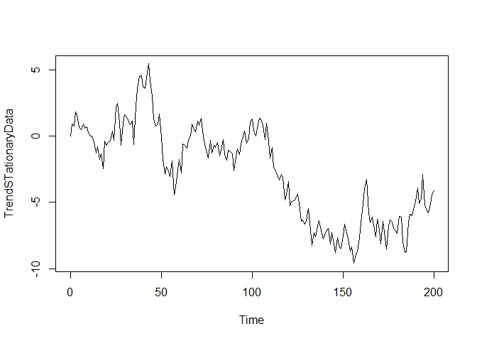

```r
TrendSTationaryData <- arima.sim(model = list(order = c(0, 1, 0)), n = 200)
plot(TrendSTationaryData)
```

Let’s try after first order differencing

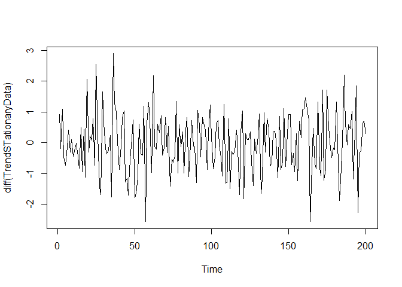

```r
plot(diff(TrendSTationaryData))
```

We can check the stationary with Dickey-Fuller Test.

```r
adf.test(diff(TrendSTationaryData)) # p-value 0.01 - stationary
```

```
##
##  Augmented Dickey-Fuller Test
##
## data:  diff(TrendSTationaryData)
## Dickey-Fuller = -5.2527, Lag order = 5, p-value = 0.01
## alternative hypothesis: stationary
```

**Seasonal Detrending** should be applied if there is seasonal trend. Let’s take a look at the example below

The *birth* dataset on example c above will not be fully detrended after one differencing. An additional seasonal differencing is what we need.

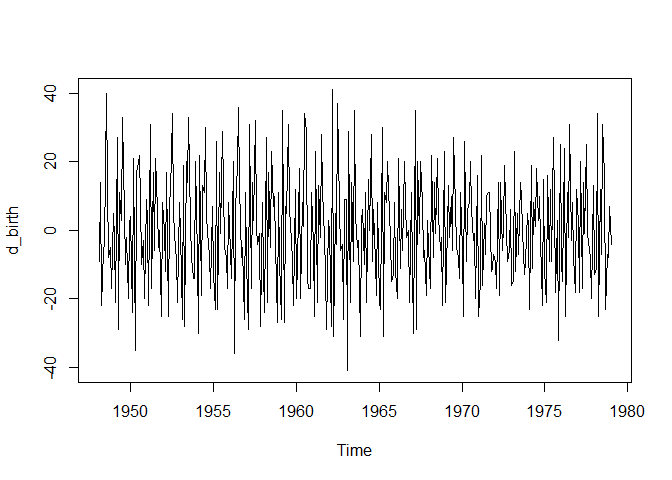

```r
d_birth <- diff(birth)
plot(d_birth) # not stationary since seasonal trend remains
```

Seasonal differencing

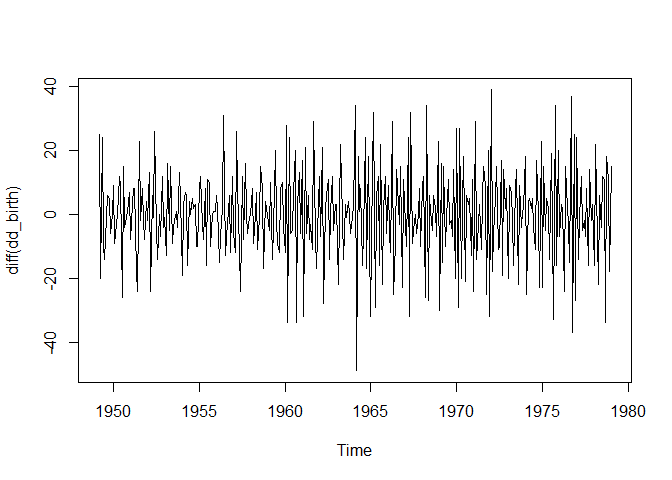

```r
dd_birth <- diff(d_birth, lag = 12) # lag  = 12 makes it seasonal differecing. 12 since monthly seasonality
plot(diff(dd_birth))
```

```r
adf.test(dd_birth) # p-value = 0.01 - stationary!
```

```
##
##  Augmented Dickey-Fuller Test
##
## data:  dd_birth
## Dickey-Fuller = -8.7804, Lag order = 7, p-value = 0.01
## alternative hypothesis: stationary
```

### b. Damping - reducing the variance

If your data has large and non-constant variance, it may help to damp the data. Taking the logarithm of the time series is one common approach.

Let’s use *djia* dataset - financial data of “Dow Jones Industrial Average” to observe this.

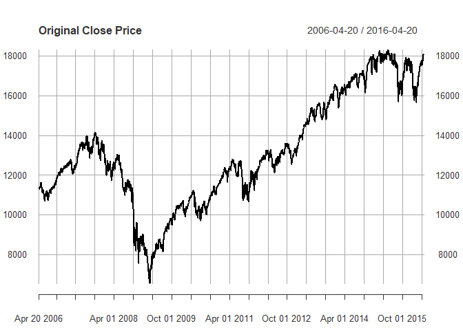

```r
plot(djia$Close,main = "Original Close Price")  # close price
```

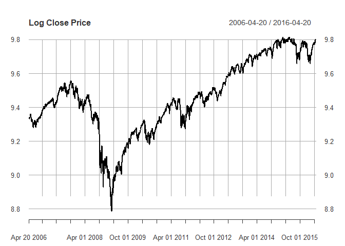

```r
plot(log((djia$Close)),main = "Log Close Price") # more constant variance
```

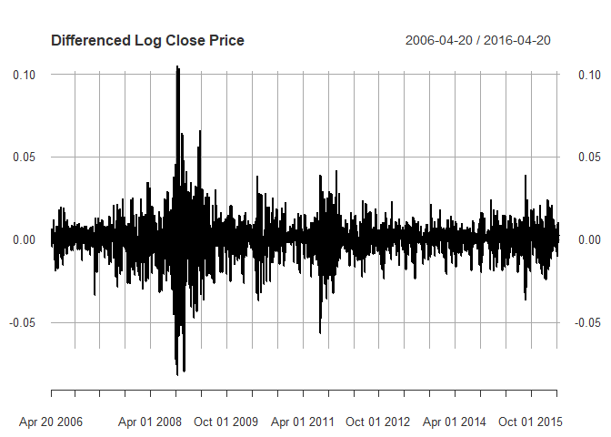

```r
plot(diff(log((djia$Close))),main = "Differenced Log Close Price")
```

## Model Selection

The list of Box-Jenkin’s models includes autoregressive - AR models, moving average - MA models, ARMA - autoregressive and moving average models, autoregressive integrated moving average models - ARIMA, seasonal ARIMA - SARIMA and others.

As the names indicate, the models depend on the nature of the data. We need to decompose the time series to see if or not autogressive, moving average, integration and seasonality are prevalent on the data.

Box-Jenkin’s models represent the components interms of combinations of letters: order = (p,d,q), seasonal = (P,D,Q), S. The parameters are found in the process of stationarizing the series.

- p - number of lags (autoregressive part)
- d - number of differencing needed
- q - number of error lags (Moving average part)
- P - number of seasonal lags (autoregressive part)
- D - number of seasonal differencing needed
- Q - number of seasonal error lags (Moving average part)
- S - seasonality

ACF (autocorrelation function) plots and PACF - partial autocorrelation function plots can be used to detect the presence of AR and MA parts. If you have applied differencing in the process of stationarizing, that indicates there is integration in your data.

d - the number of normal differencing needed, D - the number of seasonal differencings applied.

Let’s see how we can use ACF and PACF plots to find AR(p,P) and MA(q,Q) components. *acf2* function from *astsa* package returns the both plots.

Next we will apply those steps on the datasets seen above.

1. white noise

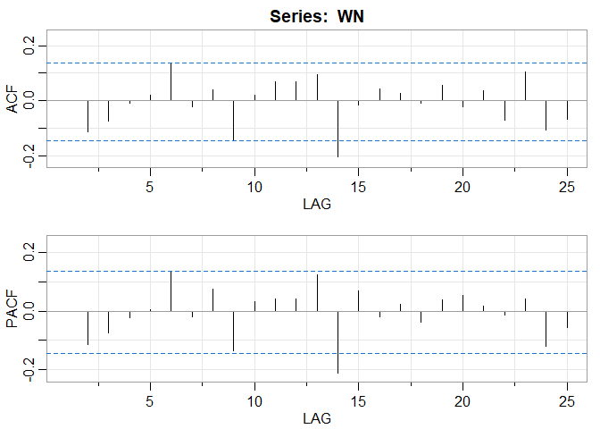

```
##      [,1]  [,2]  [,3]  [,4] [,5] [,6]  [,7] [,8]  [,9] [,10] [,11] [,12] [,13]
## ACF     0 -0.11 -0.07 -0.01 0.02 0.14 -0.02 0.04 -0.15  0.02  0.07  0.07  0.10
## PACF    0 -0.11 -0.08 -0.02 0.00 0.13 -0.02 0.07 -0.14  0.03  0.04  0.04  0.12
##      [,14] [,15] [,16] [,17] [,18] [,19] [,20] [,21] [,22] [,23] [,24] [,25]
## ACF  -0.20 -0.01  0.04  0.03 -0.01  0.06 -0.02  0.04 -0.07  0.10 -0.11 -0.07
## PACF -0.21  0.07 -0.02  0.02 -0.04  0.04  0.05  0.02 -0.01  0.04 -0.12 -0.06
```

```r
acf2(WN)
```

> Obviously the seasonal parameters are also zero. P = 0, Q = 0

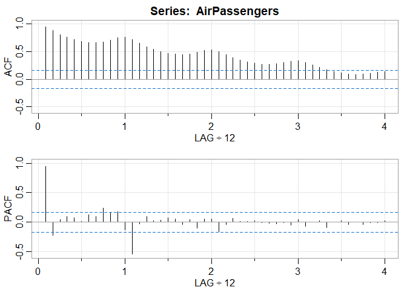

```
##      [,1]  [,2] [,3] [,4] [,5] [,6] [,7] [,8] [,9] [,10] [,11] [,12] [,13]
## ACF  0.95  0.88 0.81 0.75 0.71 0.68 0.66 0.66 0.67  0.70  0.74  0.76  0.71
## PACF 0.95 -0.23 0.04 0.09 0.07 0.01 0.13 0.09 0.23  0.17  0.17 -0.14 -0.54
##      [,14] [,15] [,16] [,17] [,18] [,19] [,20] [,21] [,22] [,23] [,24] [,25]
## ACF   0.65  0.59  0.54  0.50  0.47  0.45  0.44  0.46  0.48  0.52  0.53  0.49
## PACF -0.03  0.09  0.02  0.03  0.07  0.05 -0.05  0.05 -0.10  0.05  0.05 -0.16
##      [,26] [,27] [,28] [,29] [,30] [,31] [,32] [,33] [,34] [,35] [,36] [,37]
## ACF   0.44  0.39  0.35  0.31  0.29  0.27  0.26  0.28  0.30  0.33  0.34  0.30
## PACF -0.04  0.07  0.01  0.01  0.02 -0.01 -0.02 -0.03 -0.01 -0.05  0.05 -0.07
##      [,38] [,39] [,40] [,41] [,42] [,43] [,44] [,45] [,46] [,47] [,48]
## ACF   0.25  0.21  0.17  0.14  0.11  0.09  0.08  0.09  0.10  0.12  0.13
## PACF  0.00  0.02 -0.09  0.00  0.02 -0.04  0.00 -0.04 -0.01 -0.01  0.02
```

```r
acf2(AirPassengers)
```

> Since there if no tail off, let’s try after differencing.

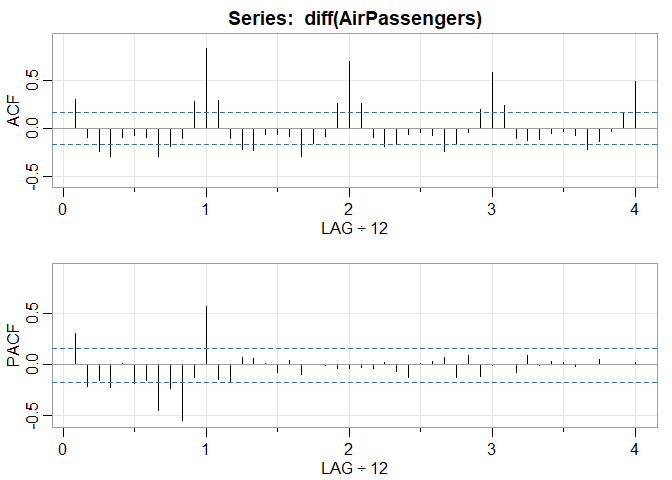

```
##      [,1]  [,2]  [,3]  [,4]  [,5]  [,6]  [,7]  [,8]  [,9] [,10] [,11] [,12]
## ACF   0.3 -0.10 -0.24 -0.30 -0.09 -0.08 -0.09 -0.29 -0.19 -0.10  0.28  0.83
## PACF  0.3 -0.21 -0.16 -0.22  0.01 -0.19 -0.15 -0.45 -0.23 -0.55 -0.13  0.57
##      [,13] [,14] [,15] [,16] [,17] [,18] [,19] [,20] [,21] [,22] [,23] [,24]
## ACF   0.28 -0.11 -0.22 -0.23 -0.06 -0.07 -0.09 -0.30 -0.16 -0.08  0.26  0.70
## PACF -0.15 -0.17  0.07  0.06  0.01 -0.08  0.04 -0.09  0.00 -0.01 -0.04 -0.04
##      [,25] [,26] [,27] [,28] [,29] [,30] [,31] [,32] [,33] [,34] [,35] [,36]
## ACF   0.26 -0.10 -0.20 -0.17 -0.07 -0.04 -0.08 -0.25 -0.16 -0.05  0.20  0.58
## PACF -0.03 -0.04  0.02 -0.06 -0.13  0.01  0.03  0.07 -0.13  0.09 -0.12 -0.01
##      [,37] [,38] [,39] [,40] [,41] [,42] [,43] [,44] [,45] [,46] [,47] [,48]
## ACF   0.23 -0.11 -0.13 -0.12 -0.05 -0.03 -0.08 -0.23 -0.14 -0.03  0.15  0.49
## PACF  0.00 -0.08  0.09 -0.01  0.03  0.02 -0.02  0.00  0.05  0.00  0.00  0.02
```

```r
acf2(diff(AirPassengers))
```

> Non-seasonal part tails off at PACF:- p = 1, d = 1, q = 0

c.a

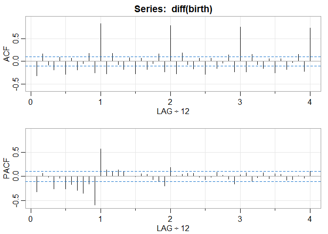

```
##       [,1] [,2]  [,3]  [,4]  [,5]  [,6]  [,7]  [,8]  [,9] [,10] [,11] [,12]
## ACF  -0.32 0.16 -0.08 -0.19  0.09 -0.28  0.06 -0.19 -0.05  0.17 -0.26  0.82
## PACF -0.32 0.06 -0.01 -0.25 -0.03 -0.26 -0.17 -0.29 -0.35 -0.16 -0.59  0.57
##      [,13] [,14] [,15] [,16] [,17] [,18] [,19] [,20] [,21] [,22] [,23] [,24]
## ACF  -0.28  0.17 -0.07 -0.18  0.08 -0.28  0.07 -0.18 -0.05  0.16 -0.24  0.78
## PACF  0.13  0.11  0.13  0.09  0.00  0.00  0.05  0.04 -0.07 -0.10 -0.20  0.19
##      [,25] [,26] [,27] [,28] [,29] [,30] [,31] [,32] [,33] [,34] [,35] [,36]
## ACF  -0.27  0.19 -0.08 -0.17  0.07 -0.29  0.07 -0.15 -0.04  0.14 -0.24  0.75
## PACF  0.01  0.05  0.07  0.07 -0.02 -0.06 -0.02  0.09  0.03 -0.06 -0.16  0.03
##      [,37] [,38] [,39] [,40] [,41] [,42] [,43] [,44] [,45] [,46] [,47] [,48]
## ACF  -0.23  0.16 -0.08 -0.15  0.05 -0.25  0.06 -0.18 -0.03  0.15 -0.22  0.72
## PACF  0.08 -0.10 -0.03  0.07 -0.04  0.06  0.04 -0.07 -0.06  0.02 -0.04  0.10
```

```r
acf2(diff(birth))
```

> Differencing is needed since acf2(birth) has too much autocorrelation AKA Never tailing off. d = 1, D = 0.

> Non-seasonal part tails off at both PACF and ACF. ( we can attempt with p =1,q = 1)

> Seasonal part tails of at both ACF and PACF (so we can start at P = 1, Q = 1)

c.b

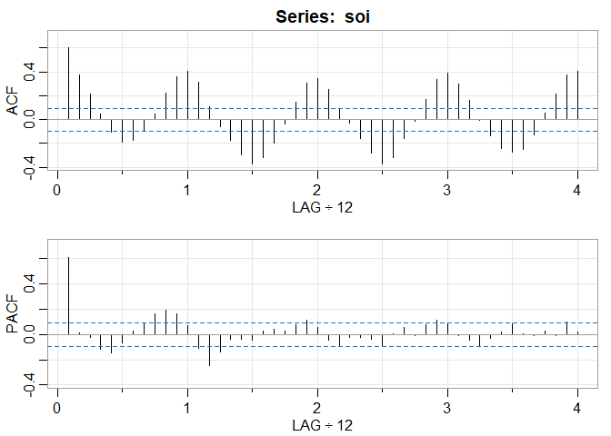

```
##      [,1] [,2]  [,3]  [,4]  [,5]  [,6]  [,7]  [,8] [,9] [,10] [,11] [,12] [,13]
## ACF   0.6 0.37  0.21  0.05 -0.11 -0.19 -0.18 -0.10 0.05  0.22  0.36  0.41  0.31
## PACF  0.6 0.01 -0.03 -0.11 -0.14 -0.06  0.03  0.09 0.16  0.19  0.17  0.07 -0.11
##      [,14] [,15] [,16] [,17] [,18] [,19] [,20] [,21] [,22] [,23] [,24] [,25]
## ACF   0.10 -0.06 -0.17 -0.29 -0.37 -0.32 -0.19 -0.04  0.15  0.31  0.35  0.25
## PACF -0.25 -0.14 -0.04 -0.04 -0.05  0.03  0.04  0.03  0.08  0.11  0.05 -0.04
##      [,26] [,27] [,28] [,29] [,30] [,31] [,32] [,33] [,34] [,35] [,36] [,37]
## ACF    0.1 -0.03 -0.16 -0.28 -0.37 -0.32 -0.16 -0.02  0.17  0.33  0.39  0.30
## PACF  -0.1 -0.02 -0.02 -0.04 -0.09  0.01  0.06 -0.01  0.08  0.11  0.09 -0.01
##      [,38] [,39] [,40] [,41] [,42] [,43] [,44] [,45] [,46] [,47] [,48]
## ACF   0.16  0.00 -0.13 -0.24 -0.27 -0.25 -0.13  0.06  0.21  0.38  0.40
## PACF -0.04 -0.09 -0.03  0.02  0.08  0.00 -0.01  0.03 -0.01  0.10  0.02
```

```r
acf2(soi)
```

> No differencing needed (d = 0, D = 0)

> non seasonal part tails of at ACF:- p = 1

> Seasonal part tails off at ACF:- P = 1

## Fitting Model

There are several R packages for time series analysis. We have discussed *forecast* package in the last blog. We will use *astsa* this time. I find *astsa* functions easier to remember and more straight forward.

The *sarima* function can handle all of the models under Box-Jenkin’s, we will only need to specify the parameters properly.

- Pure AR - sarima(data, p,0,0)
- Pure MA - sarima(data, 0,0,p)
- Pure ARMA - sarima(data, p,0,q)
- Pure ARIMA - sarima(data, p,d,q)
- Pure Seasonal - sarima(data, 0,0,0, P,D,Q, S)
- Seasonal ARIMA - sarima(data, p,d,q,P,D,Q,S)

Let’s start with the first dataset and see how we can interpret the function outputs. The above defined function parameters will be used.

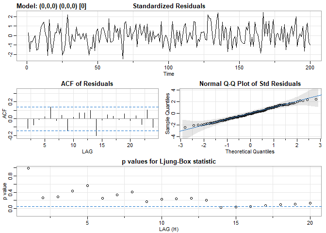

```
## $fit
##
## Call:
## arima(x = xdata, order = c(p, d, q), seasonal = list(order = c(P, D, Q), period = S),
##     xreg = xmean, include.mean = FALSE, transform.pars = trans, fixed = fixed,
##     optim.control = list(trace = trc, REPORT = 1, reltol = tol))
##
## Coefficients:
##        xmean
##       0.0220
## s.e.  0.0667
##
## sigma^2 estimated as 0.8905:  log likelihood = -272.19,  aic = 548.37
##
## $degrees_of_freedom
## [1] 199
##
## $ttable
##       Estimate     SE t.value p.value
## xmean    0.022 0.0667  0.3297   0.742
##
## $AIC
## [1] 2.741852
##
## $AICc
## [1] 2.741953
##
## $BIC
## [1] 2.774836
```

```r
sarima(WN,
       p = 0,d = 0,q = 0,
       P = 0, D = 0, Q = 0,
       S = 0

)
```

**Output interpretation**

Like in standard regressions models, the modelling is wrong if the residuals of the model do not behave like white noise. Therefore,

- *Standard Residuals Plot* - should look like that of standard white noise plot for the model to be correct.
- *ACF of residuals* - should have no spikes at all. (no autoregression should be left in the residual)
- *Q-Q plot of residuals* - should be as linear as possible.
- *p - values of Ljung-Box statistic* - should all be above the blue threshold line.

Taking another example,

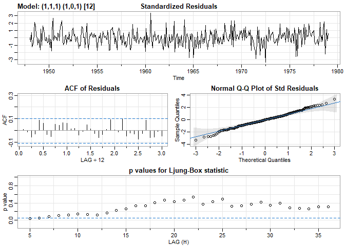

```
## $fit
##
## Call:
## arima(x = xdata, order = c(p, d, q), seasonal = list(order = c(P, D, Q), period = S),
##     xreg = constant, transform.pars = trans, fixed = fixed, optim.control = list(trace = trc,
##         REPORT = 1, reltol = tol))
##
## Coefficients:
##          ar1      ma1    sar1     sma1  constant
##       0.3144  -0.7095  0.9953  -0.7926    0.1574
## s.e.  0.0857   0.0597  0.0028   0.0461    1.7213
##
## sigma^2 estimated as 45.82:  log likelihood = -1254.64,  aic = 2521.29
##
## $degrees_of_freedom
## [1] 367
##
## $ttable
##          Estimate     SE  t.value p.value
## ar1        0.3144 0.0857   3.6686  0.0003
## ma1       -0.7095 0.0597 -11.8795  0.0000
## sar1       0.9953 0.0028 351.8634  0.0000
## sma1      -0.7926 0.0461 -17.1982  0.0000
## constant   0.1574 1.7213   0.0915  0.9272
##
## $AIC
## [1] 6.777656
##
## $AICc
## [1] 6.778096
##
## $BIC
## [1] 6.840864
```

```r
sarima(birth,
       p = 1,d = 1,q = 1,
       P = 1, D = 0, Q = 1,
       S = 12

)
```

## Forecasting

Forecasting is an easy fit once the model fit. We will use *sarima.for* function from the same package. In addition to the model parameters discussed so far, we will need the *n.ahead* parameter to specify how far ahead we would like to forecast.

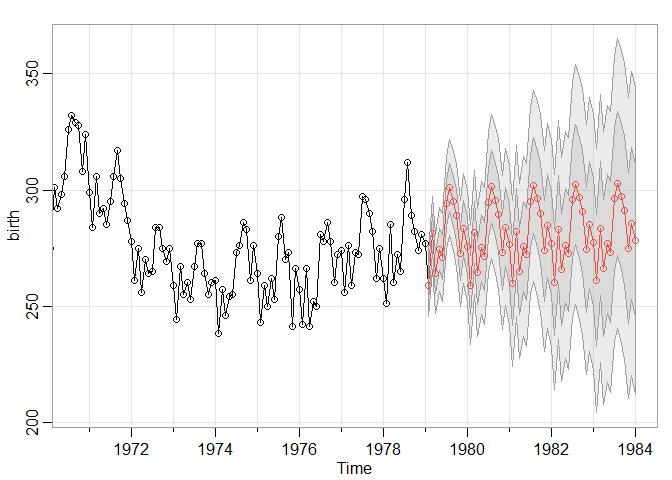

```
## $pred
##           Jan      Feb      Mar      Apr      May      Jun      Jul      Aug
## 1979          258.9307 281.4213 263.8897 274.5396 270.8916 294.3042 301.0029
## 1980 275.8587 259.0351 281.7844 264.4513 275.0874 271.4689 294.7747 301.4435
## 1981 276.4228 259.6798 282.3218 265.0717 275.6582 272.0575 295.2535 301.8914
## 1982 276.9932 260.3303 282.8657 265.6982 276.2352 272.6523 295.7391 302.3462
## 1983 277.5698 260.9867 283.4160 266.3306 276.8184 273.2533 296.2313 302.8079
## 1984 278.1527
##           Sep      Oct      Nov      Dec
## 1979 295.2148 289.0144 272.5867 283.4751
## 1980 295.6840 289.5138 273.1648 284.0023
## 1981 296.1600 290.0199 273.7491 284.5360
## 1982 296.6427 290.5325 274.3396 285.0761
## 1983 297.1321 291.0516 274.9363 285.6226
## 1984
```

[output cut: 16 more lines]

```r
sarima.for(birth,
       p = 1,d = 1,q = 1,
       P = 1, D = 0, Q = 1,
       S = 12,
       n.ahead = 5*12) # n.ahead should be number of expected data points. (5 x 12 months)
```

> While it is clear to see that the forecast captures the variations and seasonality in the data pretty well, we can use information criteria (AIC,BIC) to choose between models of similar type. The lower AIC or BIC values indicate a better-fit model.

If you have gone through this and the previous [blog](https://rpubs.com/Tesfahun_Boshe/wfmforecasting), you should have all it takes to start practicing. You can find the source code of this blog at my Github account. [Github](https://github.com/tesfahunboshe?tab=repositories)

I am crazy about data science and applying data science skills to workforce management. Feel free to reach me at [LinkedIn](https://www.linkedin.com/in/tesfahun-tegene-boshe/) if you wish to connect :)

You may as well enjoy my other blogs at [RPubs](https://rpubs.com/Tesfahun_Boshe)